# Descriptive Statistics 1: Introduction to Statistics & Describing Data

- divide stuff up to compare distributions, shapes

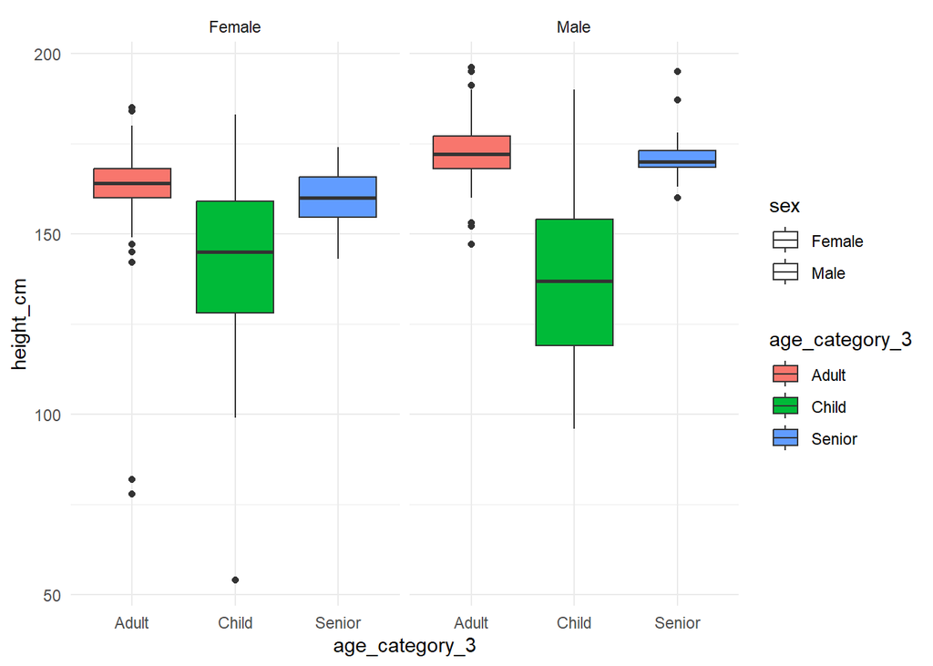

```r
# Comparing distributions across sub categories
ggplot(yaounde, aes(x = age_category_3, y = height_cm,
    fill = age_category_3,
    shape = sex)) +
  geom_boxplot() +
  facet_wrap(~sex)
```

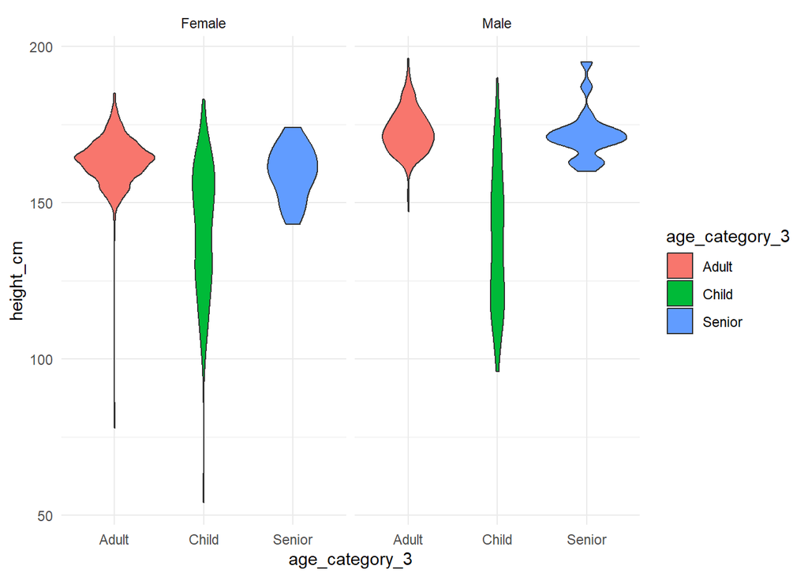

```r
# Density curve mirrored on the sides
ggplot(yaounde, aes(x = age_category_3, y = height_cm,
    fill = age_category_3,
    shape = sex)) +
  geom_violin() +
  facet_wrap(~sex)
```

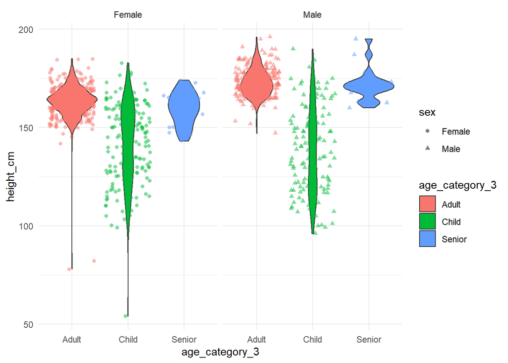

```r
# Add points
ggplot(yaounde, aes(x = age_category_3, y = height_cm,
    fill = age_category_3,
    shape = sex)) +
  geom_violin() +
  facet_wrap(~sex) +
  geom_jitter(alpha = 0.5, aes(color = age_category_3))
```

```r
# See how some of the bumps are due to just a few points (curves are normalised?)
```

**Adding mean markers to a boxplot**

You may want to visualize the mean (average) value of the distributions on a boxplot.

We can do this by adding a statistics layer using the **`stat_summary()`** function.

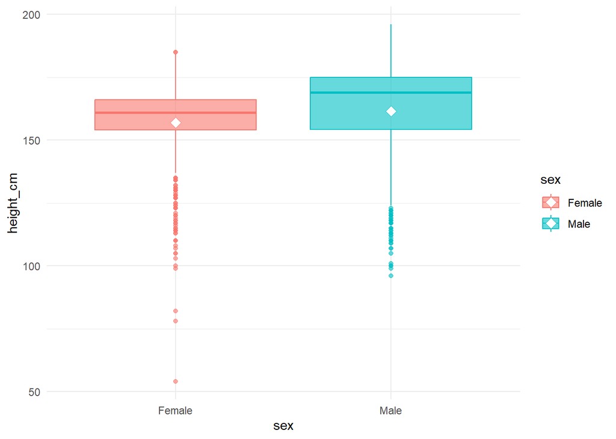

```r
# Add a marker to show the mean
ggplot(
  yaounde,
  aes(
    x = sex, height_cm,
    y = height_cm,
    fill = sex,
    color = sex
  )
) +
  geom_boxplot(alpha = 0.6) +
  stat_summary(
    fun = "mean",
    geom = "point",
    size = 3,
    shape = 23,
    fill = "white"
  )
```

**Practice**

**Plotting boxplots**

Create a boxplot showing the distribution of weights for each sex. Improve the plot by adding a layer of jittered points and a marker for the mean.

**Practice**

**Graphical methods for numeric variables**

We measured the age of 10,000 women in the UK. How would you suggest we look at the distribution of age across the sample population?

1. Produce a bar chart, with age across the x-axis and frequency on the y-axis
2. Produce a frequency table with all the ages in ascending order
3. Produce a histogram using age bins
4. Produce a bar chart, with age across the x-axis and gender across the y-axis

# Answer Key

**Identifying Variable Types**

For the four variables below, select whether it is numerical or categorical. If categorical, specify if it’s ordinal or nominal. If numerical, classify as discrete or continuous.

1. Stress level, responses are “high”, “medium”, “low”. **Categorical – Ordinal**
2. Age in years. **Numerical – Discrete**
3. Height in centimeters. **Numerical – Continuous**
4. Country name. **Categorical – Nominal**

**Identifying Variable Types**

If I measure age (in years) in a sample of 10,000 women, what type of variable would this be classified as? **Discrete**

**Identifying Variable Types and R Data Classes**

1. `age` – **Numerical (Discrete), R class: Numeric**
2. `highest_education` – **Categorical (Ordinal), R class: Character or Factor**
3. `is_smoker` – **Categorical (Nominal), R class: Character**
4. `date_surveyed` – **Date, R class: Date**
5. `weight_kg` – **Numerical (Continuous), R class: Numeric**
6. `igg_result` – **Categorical (Nominal), R class: Character**

R data classes correspond to different variable types:

| Variable Type | R Data Class | Example Variables in Yaounde Dataset |
| --- | --- | --- |
| Continuous | Numeric | `height_cm`, `weight_kg` |
| Discrete | Integer, Numeric | `age`, `n_days_miss_work` |
| Ordinal | Factor (ordered) | `highest_education` |
| Nominal | Factor, Character | `sex`, `neighborhood` |
| Logical | Logical | `is_pregnant`, `is_medicated` |
| Date | Date | `date_surveyed` |

**Frequency Tables**

Use the `tabyl()` function from the `{janitor}` package to answer the following:

1. Create a frequency table of `has_contact_covid`.

```r
yaounde %>% tabyl(has_contact_covid)
```

```
          has_contact_covid   n    percent
           No COVID contact 705 0.72605561
       Recent COVID contact  35 0.03604531
 Unsure about COVID contact 231 0.23789907
```

2. Create a two-way frequency table between `has_contact_covid` and `igg_result`.

```r
yaounde %>% tabyl(
  has_contact_covid,
  igg_result
)
```

```
          has_contact_covid Negative Positive
           No COVID contact      502      203
       Recent COVID contact       19       16
 Unsure about COVID contact      148       83
```

3. Use `adorn_percentages("row")` to display row-wise proportions in the table created above.

```r
yaounde %>%
  tabyl(
    has_contact_covid,
    igg_result
  ) %>%
  adorn_percentages("row")
```

```
          has_contact_covid  Negative  Positive
           No COVID contact 0.7120567 0.2879433
       Recent COVID contact 0.5428571 0.4571429
 Unsure about COVID contact 0.6406926 0.3593074
```

**Bar Charts**

Use `ggplot()` to create the following charts:

1. Plot a bar chart showing the distribution of `age_category_3`, colored by `is_smoker`.

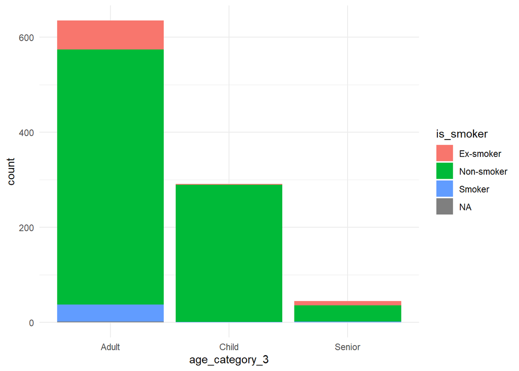

```r
ggplot(yaounde) +
  geom_bar(aes(x = age_category_3, fill = is_smoker))
```

2. Create a percent-stacked bar chart showing the same variables.

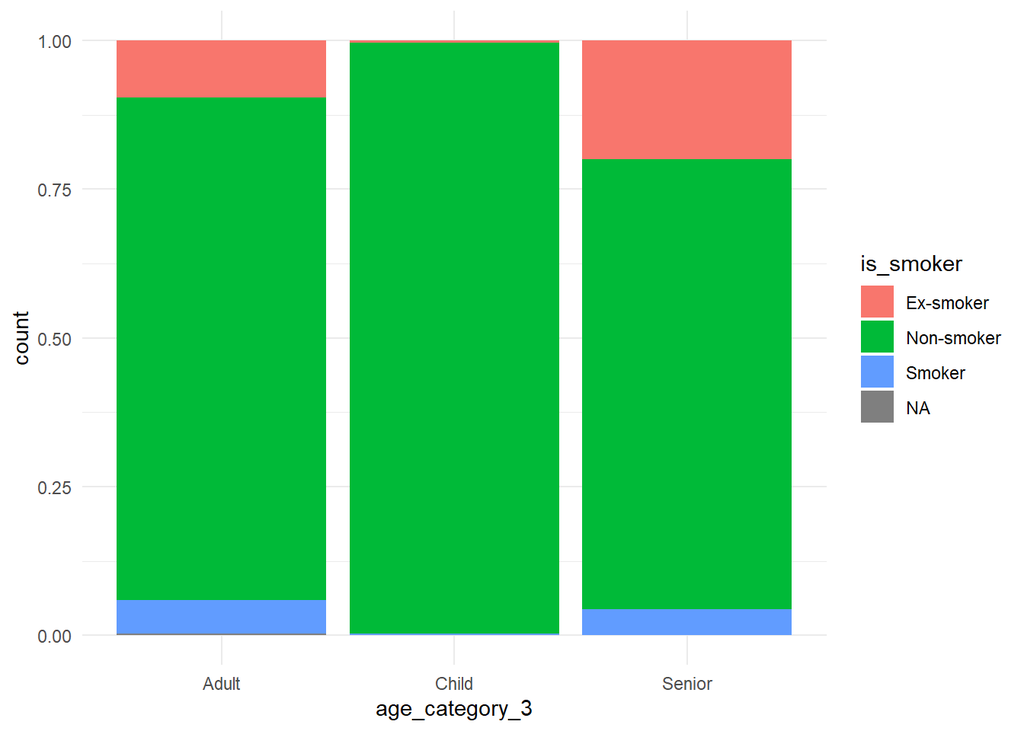

```r
ggplot(yaounde) +
  geom_bar(aes(x = age_category_3, fill = is_smoker),
    position = "fill"
  )
```

3. Reorder the `age_category_3` factor so that the categories appear in the logical order and then plot again.

```r
# Reorder categories from youngest to oldest
yaounde <- yaounde %>%
  mutate(
    age_category_3_ordered =
      factor(age_category_3,
        levels = c(
          "Child",
          "Adult",
          "Senior"
        )
      )
  )
```

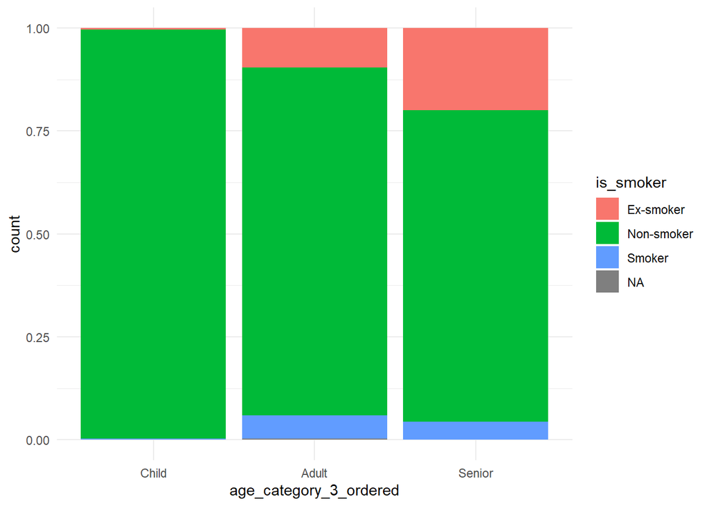

```r
# Plot again with the ordered variable
ggplot(yaounde) +
  geom_bar(
    aes(
      x = age_category_3_ordered,
      fill = is_smoker
    ),
    position = "fill"
  )
```

**Histograms**

- Plot a histogram showing the distribution of `n_bedridden_days` in `yaounde`.

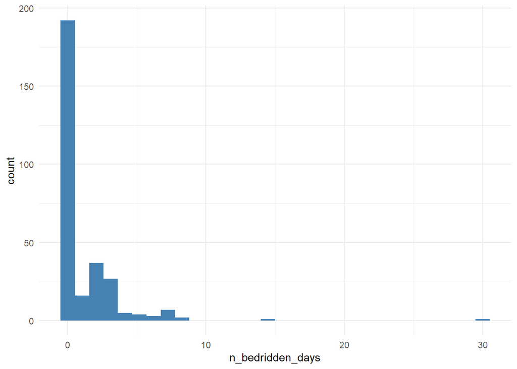

```r
ggplot(
  data = yaounde,
  mapping = aes(x = n_bedridden_days)
) +
  geom_histogram(fill = "steelblue")
```

**Density Plot: weight by sex**

- Plot a kernel density plot showing the distribution of weight for each sex in `yaounde`.

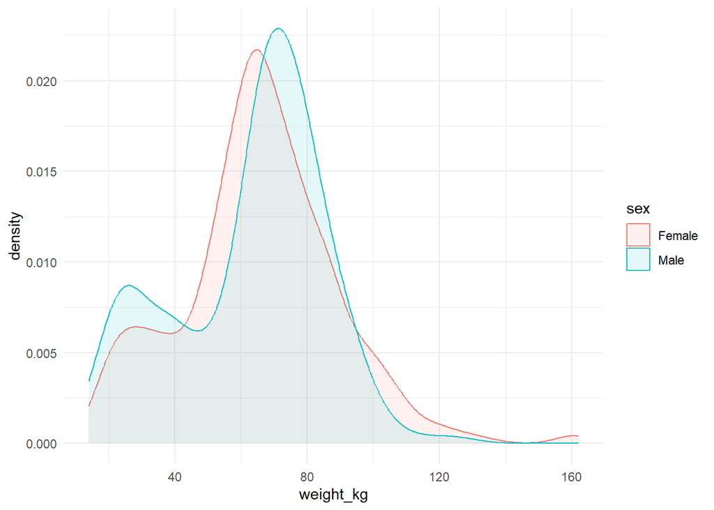

```r
ggplot(yaounde, aes(weight_kg,
  colour = sex,
  fill = sex
)) +
  geom_density(alpha = 0.1)
```

- Shows typical weight slightly differs by sex.
- Distributions largely overlap.
- Distribution is bimodal - with two peaks. Perhaps one for children and one for adults.
- Males have a slightly higher central tendency.

**Boxplots**

- Create a boxplot showing the distribution of weights for each sex. Improve the plot by adding a layer of jittered points and a marker for the mean.

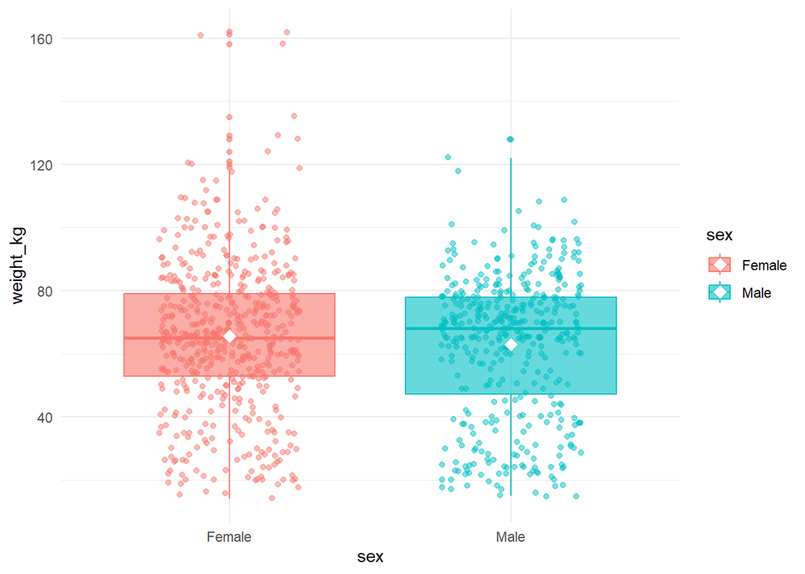

```r
ggplot(
  yaounde,
  aes(
    x = sex,
    y = weight_kg,
    fill = sex,
    color = sex
  )
) +
  geom_boxplot(alpha = 0.6) +
  geom_jitter(width = 0.25, alpha = 0.5) +
  stat_summary(
    fun = "mean",
    geom = "point",
    size = 3,
    shape = 23,
    fill = "white"
  )
```

**Graphical methods for numeric variables**

We measured the age of 10,000 women in the UK. How would you suggest we look at the distribution of age across the sample population?

1. Produce a bar chart, with age across the x-axis and frequency on the y-axis
2. Produce a frequency table with all the ages in ascending order
3. **Produce a histogram using age bins**
4. Produce a bar chart, with age across the x-axis and gender across the y-axism

# Contributors

The following team members contributed to this lesson:

- [JOY VAZ](https://thegraphcourses.org/members/joy)  
  R Instructor and Mathematical Modeller, The GRAPH Network

  Loves doing science and teaching science
- [KENE DAVID NWOSU](https://thegraphcourses.org/members/kendavidn/)  
  Data analyst, The GRAPH Network

  Passionate about world improvement

# References

Some material in this lesson was adapted from the following sources:

- Irizarry, Rafael A. 2019. *Introduction to Data Science: Statistics and Prediction Algorithms Through Case Studies*. https://rafalab.dfci.harvard.edu/dsbook-part-2/.
- Cannell, Brad, and Melvin Livingston. n.d. *R for Epidemiology*. https://www.r4epi.com/.
- GeeksforGeeks. 2025. “Introduction of Statistics and Its Types.” https://www.geeksforgeeks.org/introduction-of-statistics-and-its-types/.
- Starmer, Josh. *StatQuest with Josh Starmer* [YouTube Channel]. https://www.youtube.com/channel/UCtYLUTtgS3k1Fg4y5tAhLbw.
- The GRAPH Courses. *FoSSA: Fundamentals of Statistical Software & Analysis*. https://thegraphcourses.org/courses/fossa/.
- University of Miami Libraries. *Introduction to Data Analysis and R*. https://www.library.miami.edu/data-services/data-analysis.html.

This work is licensed under the [Creative Commons Attribution Share Alike](https://creativecommons.org/licenses/by-sa/4.0/) license.